# Statistical Inference, Part 2

Aditya Salapaka

Sunday 22 March 2015

# Hypothesis Testing on the ToothGrowth dataset

## Overivew

The ToothGrowth dataset measures the length of teeth in each of the 10 guinea pigs given three doses levels of Vitamin C (0.5, 1 and 2mg) with each of two delivery methods (orange juice and ascorbic acid). Via this document, I will try to understand the effect of Vitamin C of different dosages via different administration methods on the length of the teeth of these guinea pigs.

## Data

The ToothGrowth dataset is first loaded and observed.

```r
data(ToothGrowth)
head(ToothGrowth)
```

```
##    len supp dose
## 1  4.2   VC  0.5
## 2 11.5   VC  0.5
## 3  7.3   VC  0.5
## 4  5.8   VC  0.5
## 5  6.4   VC  0.5
## 6 10.0   VC  0.5
```

For a basic summary of the dataset:

```r
str(ToothGrowth)
```

```
## 'data.frame':    60 obs. of  3 variables:
##  $ len : num  4.2 11.5 7.3 5.8 6.4 10 11.2 11.2 5.2 7 ...
##  $ supp: Factor w/ 2 levels "OJ","VC": 2 2 2 2 2 2 2 2 2 2 ...
##  $ dose: num  0.5 0.5 0.5 0.5 0.5 0.5 0.5 0.5 0.5 0.5 ...
```

A plot of the dataset is as follows:

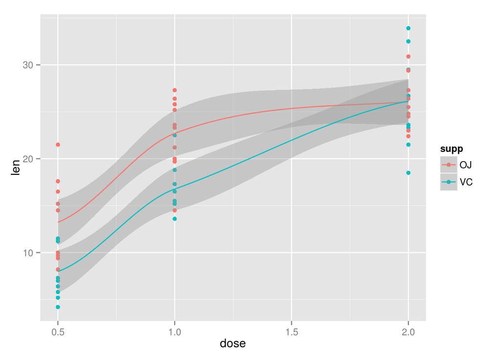

```r
require("ggplot2")
g <- ggplot(ToothGrowth, aes(dose, len))
p <- g + geom_point(aes(x = dose, y = len, colour = supp)) +
        geom_smooth(aes(colour = supp), method = "loess")
print(p)
```

The red line `OJ` represents the Orange Juice delivery method and blue line `VC` represents the Ascorbic Acid delivery method. It is clear that while there exists a significant difference between the lengths of teeth in lower dosages (with `OJ` having a greater impact), this difference is not as pronounced at higher dosages. I will attempt to verify this by hypothesis testing.

## Assumptions

Here, I assume that the populations have equal variances and the sample means are normally distributed.

## Null Hypothesis

There is no difference between the length of teeth when Vitamin C is delivered via Orange Juice or Ascorbic Acid.

I separated the ToothGrowth into two data frames `oj` and `vc`, which groups them based on the method of delivery.

```r
vc <- ToothGrowth[ToothGrowth$supp == 'VC',]
oj <- ToothGrowth[ToothGrowth$supp == 'OJ',]
```

## Hypothesis Testing

Here, I will perform the paired t test with, which has a default confidence level of 95%.

For a dosage of 0.5mg:

```r
t.test(vc$len[vc$dose == 0.5], oj$len[oj$dose == 0.5], paired = TRUE,
       var.equal = TRUE)
```

```
##
##  Paired t-test
##
## data:  vc$len[vc$dose == 0.5] and oj$len[oj$dose == 0.5]
## t = -2.9791, df = 9, p-value = 0.01547
## alternative hypothesis: true difference in means is not equal to 0
## 95 percent confidence interval:
##  -9.236542 -1.263458
## sample estimates:
## mean of the differences
##                   -5.25
```

The 95% confidence values gives the interval -9.23 to -1.26, and the mean of the differences is -5.25. The p-value is 0.015, which is lesser than 0.05. So we can reject the null hypothesis for a dosage of 0.5mg. Therefore, different methods of administration does make a difference in the length of teeth of guinea pigs, for a dosage of 0.5mg.

For a dosage of 1mg:

```r
t.test(vc$len[vc$dose == 1], oj$len[oj$dose == 1], paired = TRUE,
       var.equal = TRUE)
```

```
##
##  Paired t-test
##
## data:  vc$len[vc$dose == 1] and oj$len[oj$dose == 1]
## t = -3.3721, df = 9, p-value = 0.008229
## alternative hypothesis: true difference in means is not equal to 0
## 95 percent confidence interval:
##  -9.908089 -1.951911
## sample estimates:
## mean of the differences
##                   -5.93
```

The 95% confidence values gives the interval -9.91 to -1.95, and the mean of the differences is -5.93. The p-value is 0.008, which is lesser than 0.01. So we can reject the null hypothesis for a dosage of 1mg. Therefore, different methods of administration does make a difference in the length of teeth of guinea pigs, for a dosage of 1mg.

For a dosage of 2mg:

```r
t.test(vc$len[vc$dose == 2], oj$len[oj$dose == 2], paired = TRUE,
       var.equal = TRUE)
```

```
##
##  Paired t-test
##
## data:  vc$len[vc$dose == 2] and oj$len[oj$dose == 2]
## t = 0.0426, df = 9, p-value = 0.967
## alternative hypothesis: true difference in means is not equal to 0
## 95 percent confidence interval:
##  -4.168976  4.328976
## sample estimates:
## mean of the differences
##                    0.08
```

## Conclusion

From the hypothesis test, we have concluded that for dosages of 0.5mg and 1mg, the method of delivery affects the length of teeth in guinea pigs. However, this does not hold true for 2mg.